# Analiza Mistrzostw Świata w Piłce Nożnej

Hubert Gogola

2024-12-03

# Wprowadzenie

Moja analiza została wykonana na danych opierających się na najwiekszej imprezie w piłce nożnej czyli Mistrzostw Świata. Postanowiłem podjąć się tego tematu ponieważ piłka nożna to moja pasja która towarzyszy mi od najmłodszych lat.

W swojej pracy korzystam z danych: https://www.kaggle.com/datasets/iamsouravbanerjee/fifa-football-world-cup-dataset

Jest to aktalny zestaw danych zawierający informacje z wszystkich Mistrzostw Świata w Piłce Nożnej od roku 1930 do 2022 czyli z 22 turniejów.

Dane posiadają następujące kolumny:

- **YEAR**: Rok turnieju
- **HOST**: Kraj gospodarza
- **CHAMPION**: Kraj mistrza
- **RUNNER UP**: Kraj wicemistrza
- **THIRD PLACE**: Kraj na trzecim miejscu
- **TEAMS**: Liczba drużyn uczestniczących
- **MATCHES PLAYED**: Liczba rozegranych meczów
- **GOALS SCORED**: Liczba strzelonych bramek
- **AVG GOALS PER GAME**: Średnia liczba bramek na mecz

# Pakiety z których korzystam:

```r
library(dplyr)
library(ggplot2)
library(reshape2)
library(tidyr)
library(treemapify)
library(magrittr)
library(ggcorrplot)
```

# Wstępna Analiza

Na początku wczytuje dane z pliku CSV i zapisuje ramke danych w obiekcie dane.

```r
dane <- read.csv("Word Cup.csv", header = TRUE, sep = ",", stringsAsFactors = FALSE)
```

Pogląd pierwszych wierszy danych (przykładowo użyłem 5)

```r
head(dane, 5)
```

```
##   YEAR        HOST     CHAMPION      RUNNER.UP   THIRD.PLACE TEAMS
## 1 1930     Uruguay      Uruguay      Argentina United States    13
## 2 1934       Italy        Italy Czechoslovakia       Germany    16
## 3 1938      France        Italy        Hungary        Brazil    15
## 4 1950      Brazil      Uruguay         Brazil        Sweden    13
## 5 1954 Switzerland West Germany        Hungary       Austria    16
##   MATCHES.PLAYED GOALS.SCORED AVG.GOALS.PER.GAME
## 1             16           70                3.6
## 2             17           70                4.1
## 3             18           84                4.7
## 4             22           88                4.0
## 5             26          140                5.4
```

Sprawdzam strukturę danych oraz ich typ w kolumnach, czy są w postaci liczbowych, tekstowych czy logicznych

```r
str(dane)
```

```
## 'data.frame':    22 obs. of  9 variables:
##  $ YEAR              : int  1930 1934 1938 1950 1954 1958 1962 1966 1970 1974 ...
##  $ HOST              : chr  "Uruguay" "Italy" "France" "Brazil" ...
##  $ CHAMPION          : chr  "Uruguay" "Italy" "Italy" "Uruguay" ...
##  $ RUNNER.UP         : chr  "Argentina" "Czechoslovakia" "Hungary" "Brazil" ...
##  $ THIRD.PLACE       : chr  "United States" "Germany" "Brazil" "Sweden" ...
##  $ TEAMS             : int  13 16 15 13 16 16 16 16 16 16 ...
##  $ MATCHES.PLAYED    : int  16 17 18 22 26 35 32 32 32 38 ...
##  $ GOALS.SCORED      : int  70 70 84 88 140 126 89 89 95 97 ...
##  $ AVG.GOALS.PER.GAME: num  3.6 4.1 4.7 4 5.4 3.6 2.8 2.8 3 2.6 ...
```

Wykonuje sumowanie podstawowych danych statystycznych takich jak: minimum, maksimum, mediana, średnia, pierwszy i trzeci kwartyl. Tym sposobem dostarczam ogólnego wglądu w dane czy np. nie występują wartości odstające oraz sprawdzam czy nie brakuje danych.

```r
summary(dane)
```

```
##       YEAR          HOST             CHAMPION          RUNNER.UP
##  Min.   :1930   Length:22          Length:22          Length:22
##  1st Qu.:1959   Class :character   Class :character   Class :character
##  Median :1980   Mode  :character   Mode  :character   Mode  :character
##  Mean   :1979
##  3rd Qu.:2001
##  Max.   :2022
##  THIRD.PLACE            TEAMS       MATCHES.PLAYED   GOALS.SCORED
##  Length:22          Min.   :13.00   Min.   :16.00   Min.   : 70.0
##  Class :character   1st Qu.:16.00   1st Qu.:32.00   1st Qu.: 90.5
##  Mode  :character   Median :20.00   Median :45.00   Median :129.0
##                     Mean   :22.23   Mean   :43.73   Mean   :123.6
##                     3rd Qu.:32.00   3rd Qu.:64.00   3rd Qu.:146.8
##                     Max.   :32.00   Max.   :64.00   Max.   :172.0
##  AVG.GOALS.PER.GAME
##  Min.   :2.200
##  1st Qu.:2.600
##  Median :2.700
##  Mean   :3.059
##  3rd Qu.:3.450
##  Max.   :5.400
```

```r
any(is.na(dane))
```

```
## [1] FALSE
```

# Trendy drużyn

Na początku podejmuję się badaniem trendów na mundialu w piłce nożnej. Trendy zmieniają się wraz z ewolucją taktyki, technologii i stylu gry. Podstawowe wizualizacje pozwalają na łatwe dostrzeżenie zmian w kluczowych zmiennych na przestrzeni lat. Najważniejszymi czynnikami nad którymi się skupię w tej tematyce to trend liczby drużyn, rozegranych meczów i bramek oraz zmiana średniej liczby goli na mecz w całej historii imprezy.

### Czy liczba drużyn, meczów i bramek znacząco się zmieniała?

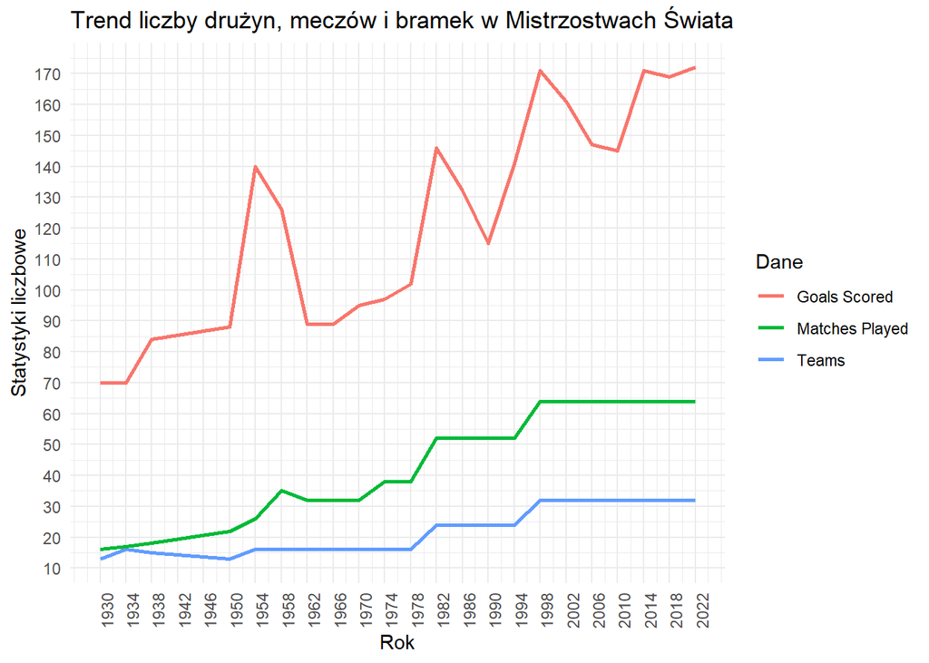

```r
ggplot(dane, aes(x = YEAR)) +
  geom_line(aes(y = TEAMS, color = "Teams"), size = 1) +
  geom_line(aes(y = MATCHES.PLAYED, color = "Matches Played"), size = 1) +
  geom_line(aes(y = GOALS.SCORED, color = "Goals Scored"), size = 1) +
    scale_x_continuous(breaks = seq(1930, 2022, by = 4)) +
    scale_y_continuous(breaks = seq(0,200, by = 10)) +
  labs(title = "Trend liczby drużyn, meczów i bramek w Mistrzostwach Świata",
       x = "Rok",
       y = "Statystyki liczbowe",
       color = "Dane") +
  theme_minimal() +
  theme(axis.text.x = element_text(angle = 90, hjust = 1))
```

### Czy średnia liczba goli na mecz się również zwiększyła?

[figure not shown]

```r
ggplot(dane, aes(x = YEAR, y = AVG.GOALS.PER.GAME)) +
  geom_line(color = "purple", linewidth = 1) +
  geom_point(color = "purple", size = 2) +
  scale_x_continuous(breaks = seq(1930,2022, by = 4)) +
  labs(title = "Średnia liczba goli na mecz (1930-2018)",
       x = "Rok",
       y = "Średnia ilośc goli na mecz") +
  theme_minimal() +
theme(axis.text.x = element_text(angle = 50, hjust = 1))
```

Łatwo można zauważyć wzrost goli, meczów i drużyn. Jednak zadałem sobie pytanie czy jeśli zwiększone zostały te parametry, to czy średnia liczba goli na mecz również się powiększyła? Do tego badania użyję zmiennej AVG GOALS PER GAME czyli inaczej średnia liczba goli na mecz, badam ją na przestrzeni lat. Na tej podstawie zauważam ciekawą zależność. Choć liczba bramek rosła wraz z liczbą meczów, średnia liczba goli na mecz zaczęła się stabilozować w nowoczesnych turniejach. To wskazuje na bardziej defensywną strategię gry współczesnych drużyn. Średnia liczba goli na mecz była najwyższa na mundialu w 1954 roku i wynosiła ona ponad 5 goli. Od lat 60, widoczny jest stopniowy spadek oraz stabilizacja na poziomie około 2,5 gola na mecz. Spadek jest wynikiem większej konkurecnji i lepszej strategii.

# Wyniki poszczególnych drużyn

Analizuję teraz poszczególne drużyny które występowały na największej imprezie w piłce nożnej. Jednym z kluczowych aspektow jest sukces poszczegolnych reprezentacji. Wiadomo że każdy kraj ma inne oczekiwania wobec swojej reprezentacji. Najważniejszy jednak jest wynik i końcowy sukces. Analiza ta pozwoli mi zidentyfikować kraje, które najczęsniej wygrywały ten turniej.

### Które drużyny zdobywały tytuł mistrza świata najwięcej razy?

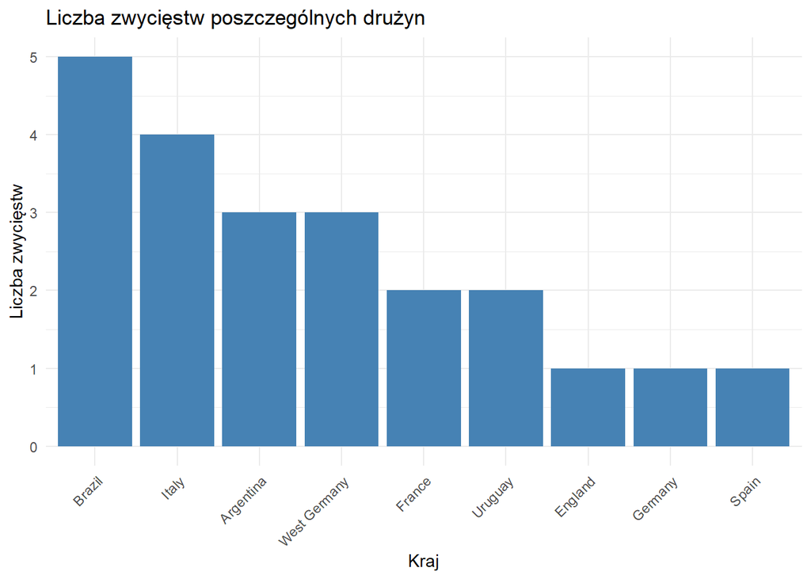

```r
dane %>%
  count(CHAMPION) %>%
  ggplot(aes(x = reorder(CHAMPION, -n), y = n)) +
  geom_bar(stat = "identity", fill = "steelblue") +
  labs(title = "Liczba zwycięstw poszczególnych drużyn",
       x = "Kraj",
       y = "Liczba zwycięstw") +
  theme_minimal() +
  theme(axis.text.x = element_text(angle = 45, hjust = 1))
```

Reprezentacja Brazyli jest liderem w klasyfikacji zwycięstw na tej imprezie zdobywając 5 tytułow mistrzowskich. W czołówce są również takie kraje jak: Włochy, Argentyna, Niemcy czy Francja.

### Jakie zespoły zajęły 2 i 3 miejsce w całej historii turnieju?

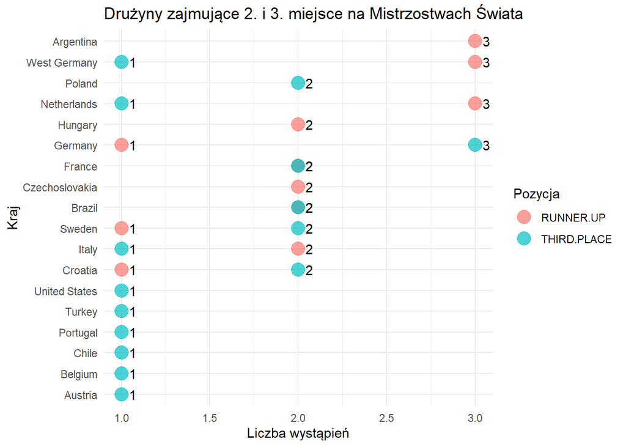

```r
druzyny_miejsca <- dane %>%
  select(YEAR, RUNNER.UP, THIRD.PLACE) %>%
  pivot_longer(cols = c(RUNNER.UP, THIRD.PLACE),
               names_to = "Pozycja",
               values_to = "Kraj") %>%
  count(Kraj, Pozycja)

# Wykres punktowy
ggplot(druzyny_miejsca, aes(x = n, y = reorder(Kraj, n), color = Pozycja)) +
  geom_point(size = 5, alpha = 0.7) +
  geom_text(aes(label = n), hjust = -1, color = "black") +
  labs(title = "Drużyny zajmujące 2. i 3. miejsce na Mistrzostwach Świata",
       x = "Liczba wystąpień",
       y = "Kraj",
       color = "Pozycja",) +
  theme_minimal() +
  theme(axis.text.x = element_text(angle = 0, hjust = 0.5))
```

```r
print(druzyny_miejsca)
```

```
## # A tibble: 26 × 3
##    Kraj           Pozycja         n
##    <chr>          <chr>       <int>
##  1 Argentina      RUNNER.UP       3
##  2 Austria        THIRD.PLACE     1
##  3 Belgium        THIRD.PLACE     1
##  4 Brazil         RUNNER.UP       2
##  5 Brazil         THIRD.PLACE     2
##  6 Chile          THIRD.PLACE     1
##  7 Croatia        RUNNER.UP       1
##  8 Croatia        THIRD.PLACE     2
##  9 Czechoslovakia RUNNER.UP       2
## 10 France         RUNNER.UP       2
## # ℹ 16 more rows
```

Wykres punktowy czyli Dolt Plot jest dobrym sposobem na wizualizacje częstości wystąpień, gdzie każda drużyna zajmująca 2 lub 3 miejsce jest reprezentowana przez punkty ułożone na osi poziomej. Czerwona Kropka - 2 miejsce w trunieju. Niebieska Kropka - 3 miejsce w turnieju. Polska zdobyła dwa razy w swojej historii trzecie miejsce na mistrzostwach.

# Analiza sukcesów gospodarzy

### Czy często gospodarze odnoszą sukces na mundialu?

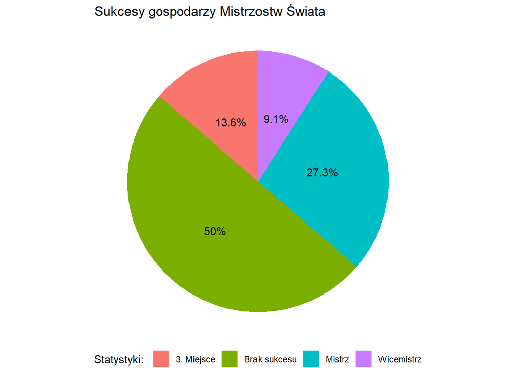

```r
sukcesy_gospodarzy <- dane %>%
  mutate(Sukces = ifelse(HOST == CHAMPION, "Mistrz",
                  ifelse(HOST == RUNNER.UP, "Wicemistrz",
                  ifelse(HOST == THIRD.PLACE, "3. Miejsce",
                         "Brak sukcesu")))) %>%
  count(Sukces)

sukcesy_gospodarzy <- sukcesy_gospodarzy %>%
  mutate(Procent = n / sum(n) * 100)

ggplot(sukcesy_gospodarzy, aes(x = "", y = Procent, fill = Sukces)) +
  geom_bar(stat = "identity", width = 1) +
  coord_polar(theta = "y") +
  geom_text(aes(label = paste0(round(Procent, 1), "%")),
            position = position_stack(vjust = 0.5)) +
  labs(title = "Sukcesy gospodarzy Mistrzostw Świata",
       fill = "Statystyki: ",
       x = NULL, y = NULL) +
  theme_void() +
  theme(legend.position = "bottom")
```

```r
print(sukcesy_gospodarzy)
```

```
##         Sukces  n   Procent
## 1   3. Miejsce  3 13.636364
## 2 Brak sukcesu 11 50.000000
## 3       Mistrz  6 27.272727
## 4   Wicemistrz  2  9.090909
```

Występuje zależność pomiędzy sukcesem na mistrzostwach swiata a bycie gospodarzem tego turnieju. Gospodarze wygrywali w około 27% przypadkach czyli w 6 na 22 turniejów. Wicemistrzami byli około 9% razy a 3 miejsce zajmowali ponad 13%. Pomimo przewagi własnego boiska, gospodarze często też kończyli turniej bez medalu. Jednak trzeba pamiętać, że w wielu przypadkach były to drużyny o słabych wynikach np. RPA, Rosja czy ostatnie mistrzostwa świata w Katarze. Warto podkreślić, że historia pokazuje pewną przewagę gospodarzy w porównaniu z innymi drużynami.

### Czy gospodarze mistrzostw świata w piłce nożnej zdobywają średnio więcej goli na mecz niż drużyny, które nie są gospodarzami?

```r
dane_gole <- dane %>%
  mutate(Gospodarz = ifelse(HOST == CHAMPION | HOST == RUNNER.UP | HOST == THIRD.PLACE, "Gospodarz", "Goście"))

t_test_gole <- t.test(AVG.GOALS.PER.GAME ~ Gospodarz, data = dane_gole, alternative = "greater")
print(t_test_gole)
```

```
##
##  Welch Two Sample t-test
##
## data:  AVG.GOALS.PER.GAME by Gospodarz
## t = -0.12519, df = 17.428, p-value = 0.5491
## alternative hypothesis: true difference in means between group Gospodarz and group Goście is greater than 0
## 95 percent confidence interval:
##  -0.6761978        Inf
## sample estimates:
## mean in group Gospodarz    mean in group Goście
##                3.036364                3.081818
```

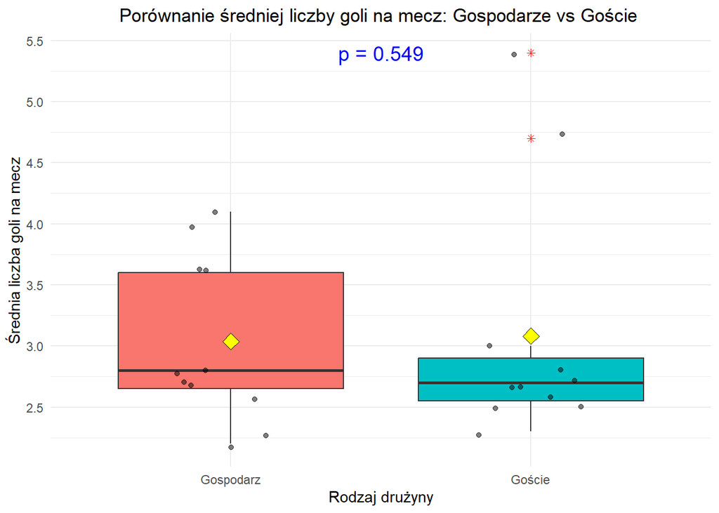

```r
ggplot(dane_gole, aes(x = Gospodarz, y = AVG.GOALS.PER.GAME, fill = Gospodarz)) +
  geom_boxplot(outlier.color = "red", outlier.shape = 8) +
  stat_summary(fun = mean, geom = "point", shape = 23, size = 4, fill = "yellow") +
  geom_jitter(width = 0.2, alpha = 0.5, color = "black") +
  scale_y_continuous(breaks = seq(1, 6, by = 0.5)) +
  labs(title = "Porównanie średniej liczby goli na mecz: Gospodarze vs Goście ",
       x = "Rodzaj drużyny",
       y = "Średnia liczba goli na mecz") +
  theme_minimal() +
  theme(legend.position = "none", plot.title = element_text(hjust = 0.5)) +
  annotate("text", x = 1.5, y = max(dane_gole$AVG.GOALS.PER.GAME),
           label = paste0("p = ", round(t_test_gole$p.value, 3)), color = "blue", size = 5)
```

# Analiza poszczególnych kontynentów na mistrzostwach świata

Analiza udziału kontynentów pozwala odpowiedzieć na pytania dotyczące ich wkładu w historię turnieju, a także ocenić, które regiony dominowały w określonych epokach piłki nożnej. Trzeba przyznać, że różnorodność kontyntnów przynosi świetny klimat dla takiej imprezy.

### Który kontynent najczęściej organizuje mundial?

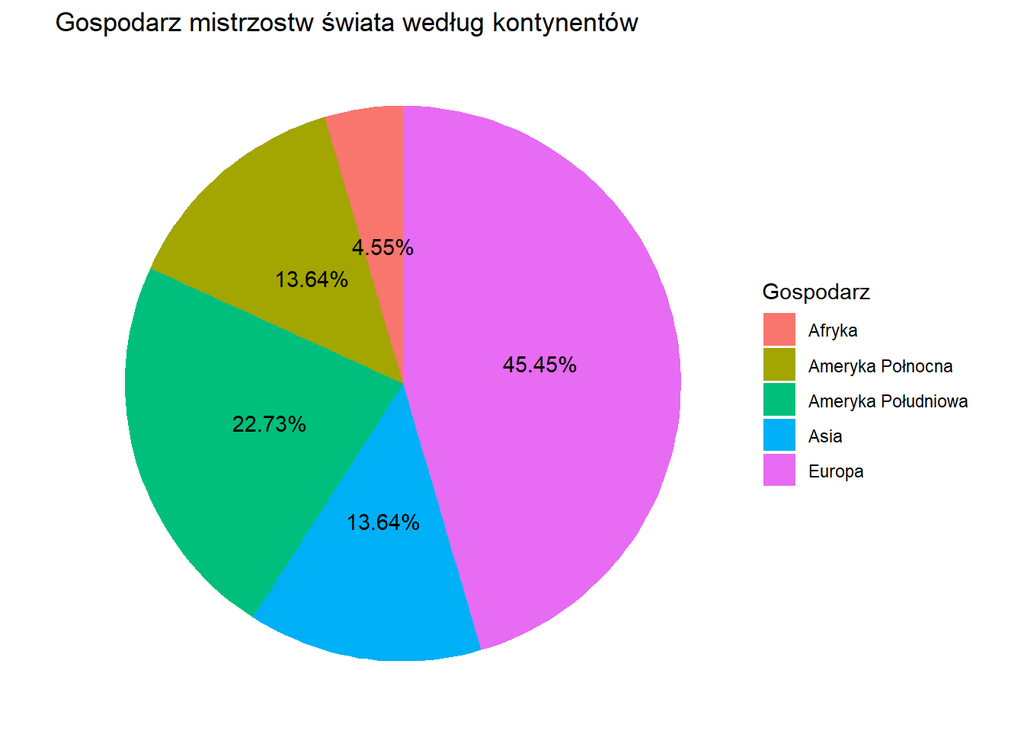

```r
wc_summ <- data.frame(
  Gospodarz = c(rep("Europa", 10), rep("Ameryka Południowa", 5), rep("Ameryka Połnocna", 3), rep("Asia", 3), "Afryka")
)

table <- wc_summ %>% count(Gospodarz)
table <- table %>% arrange(desc(n))

ggplot(table, aes(x = "", y = n, fill = Gospodarz)) +
  geom_bar(stat = "identity", width = 1) +
  coord_polar(theta = "y") +
  labs(title = "Gospodarz mistrzostw świata według kontynentów", x = NULL, y = NULL) +
  geom_text(aes(label = scales::percent(n / sum(n), accuracy = 0.01)), position = position_stack(vjust = 0.5)) +
  theme_void()
```

Z poniższego wykresu kołowego zauważamy znaczącą zależność gospodarza kontynentu mistrzostw świata. Europa jest najczęstrzym wyborem organizacji tej imprezy 10 turniejów ponad 45%. Ameryka Południowa jest drugim najczęstrzym wyborem. Ameryka Północna i Azja mialy po 3 edycje tej imprezy. Afryka była tylko raz gospodarzem (turniej odbył się w RPA w 2010 roku).

### Które kontynenty wygrywały mistrzostwa świata i ile razy?

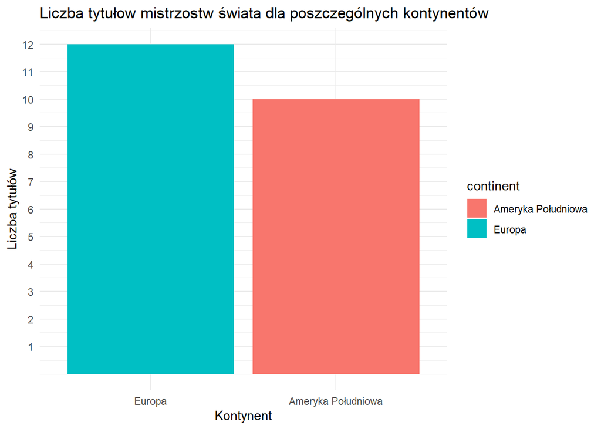

```r
world_cup_data <- data.frame(
  YEAR = c(1930, 1934, 1938, 1950, 1954, 1958, 1962, 1966, 1970, 1974, 1978, 1982, 1986, 1990, 1994, 1998, 2002, 2006, 2010, 2014, 2018, 2022),
  CHAMPION = c("Uruguay", "Italy", "Italy", "Uruguay", "West Germany", "Brazil", "Brazil", "England", "Brazil", "West Germany", "Argentina", "Italy", "Argentina", "West Germany", "Brazil", "France", "Brazil", "Italy", "Spain", "Germany", "France", "Argentina")
)

continent_mapping <- data.frame(
  team = c("Uruguay", "Argentina", "Brazil", "Italy", "West Germany", "Germany", "England", "France", "Spain"),
  continent = c("Ameryka Południowa", "Ameryka Południowa", "Ameryka Południowa", "Europa", "Europa", "Europa", "Europa", "Europa", "Europa")
)

world_cup_data <- world_cup_data %>%
  mutate(continent = continent_mapping$continent[match(CHAMPION, continent_mapping$team)])

continent_counts <- world_cup_data %>%
  group_by(continent) %>%
  tally(name = "titles") %>%
  arrange(desc(titles))

ggplot(continent_counts, aes(x = reorder(continent, -titles), y = titles, fill = continent)) +
  geom_bar(stat = "identity") +
  theme_minimal() +
  scale_y_continuous(breaks = seq(1, 14, by = 1)) +
  labs(title = "Liczba tytułow mistrzostw świata dla poszczególnych kontynentów",
       x = "Kontynent",
       y = "Liczba tytułów")
```

Europa dominuje w liczbie tytyłow. Kontynent ten triumfował 12 razy. Ameryka Południowa również znacząco nie odstaje i posiada 10 wygranych turniejów. Mimo wszystko te dwa kontynenty tylko wygrywały mistrzostwa. Żadnej drużynie z Ameryki Północnej, Azji czy Afryki nie udało się zdobyć wymarzonego pucharu. Pokazuje też to, że od początku dziejów piłki nożnej w tym temacie nic się nie zmieniło i dominują tylko dwa kontynenty.

# Heatmapa - korelacja danych

Korelacja mierzy stopień, w jakim dwie zmienne są ze sobą powiązane. W kontekście turnieju mistrzostw świata, badanie korelacji między takimi danymi, jak liczba drużyn, liczba rozegranych meczów, liczba strzelonych goli czy średnia liczba goli na mecz, pozwala na wyciąganie wniosków o zależnościach między różnymi aspektami rywalizacji.

### Jakie występują zależności dla innych statystyk?

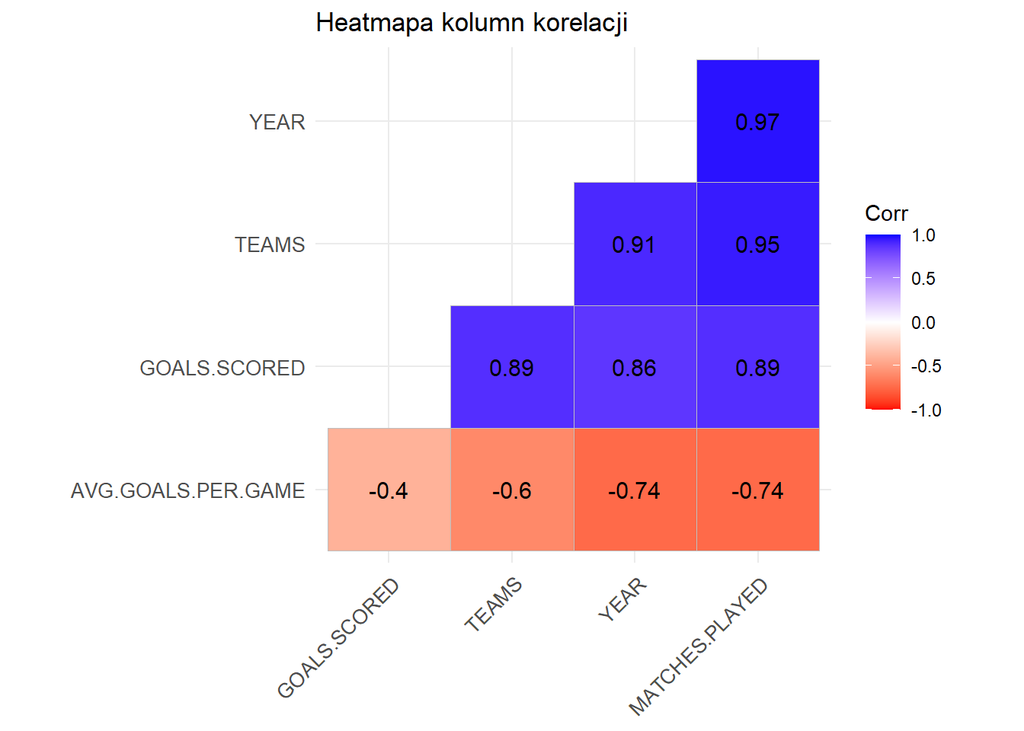

```r
cor_matrix <- cor(dane[, sapply(dane, is.numeric)], use = "complete.obs")

ggcorrplot(cor_matrix,
           hc.order = TRUE,
           type = "lower",
           lab = TRUE,
           colors = c("red", "white", "blue"),
           title = "Heatmapa kolumn korelacji",
           tl.cex = 10)
```

## Zakończenie

Przeprowadzona analiza pokazała, że mistrzostwa świata w piłce nożnej nie tylko stanowią ważne wydarzenie sportowe, ale również dostarczają bogatego materiału do analiz statystycznych, które pozwalają na zrozumienie, jak zmieniały się kluczowe aspekty tego turnieju na przestrzeni lat. Wyniki tej analizy mogą stanowić punkt wyjścia do dalszych badań i analiz, np. w kontekście wpływu konkretnych drużyn na wyniki mistrzostw, czy wpływu organizacji turnieju na wyniki drużyn. Warto zauważyć, że pokazana analiza przedstawia również trendy w piłce nożnej które pokazują zmiane strategi drużyn czy wzrost intensywności.